# Math 365 / Comp 365: Activity 3

# Introduction to the Limits of Accuracy

### Objectives

- Practice using root-finding algorithms
- Gain exposure to issues of numerical accuracy

This activity is related to the discussion in Section 1.3.

### Example 1: *Root-finding in the presence of multiple roots*

Consider the polynomial

$$f(x)=x^3-2x^2+\frac{4}{3}x-\frac{8}{27}=(x-\frac{2}{3})^3$$

Let’s have a look at the function:

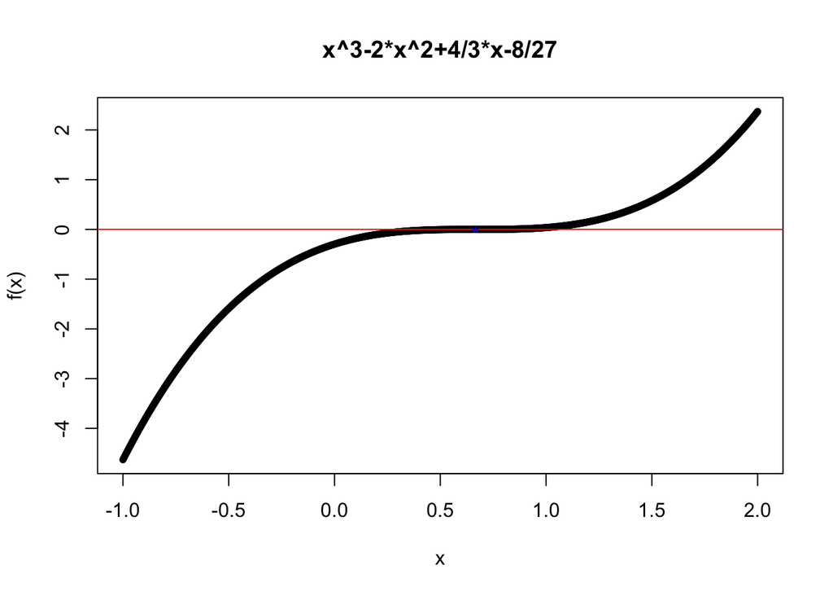

```r
x = seq(-1,2,len=1000)
f=function(x) {x^3-2*x^2+4/3*x-8/27}
plot(x,f(x),pch=20,main="x^3-2*x^2+4/3*x-8/27")
abline(0,0,col="red")
points(2/3,0,col="blue",pch="*")
```

1. Discuss with a neighbor to understand what each line in the plotting code is doing. If you are confused, you can use R help, see the link to graphics in R on Moodle or Google R plotting instructions.
2. Use your bisection method code to find the root. Use a starting interval of $[0,1]$ and a tolerance of $0.5*10^{-10}$. Also run this command, which will change the number of digits that R displays on output.

My bisection method resulted in a root of 0.6666641 with the parameters intervale = c(0, 1), tol = 0.5e-10, and the above funtion. It took 17 iterations.

```r
options(digits=10)
```

How close is the answer to the actual root of $\frac{2}{3}$?

Almost exact.

3. Try to find the root with the R function `uniroot`. Is that any closer?

```r
interval = c(0, 1)
tol = 0.5e-10
uniroot(f, interval, tol = tol)
```

```
## $root
## [1] 0.6666694578
##
## $f.root
## [1] 0
##
## $iter
## [1] 35
##
## $init.it
## [1] NA
##
## $estim.prec
## [1] 1.677940638e-05
```

4. Now let’s zoom in very close to the root:

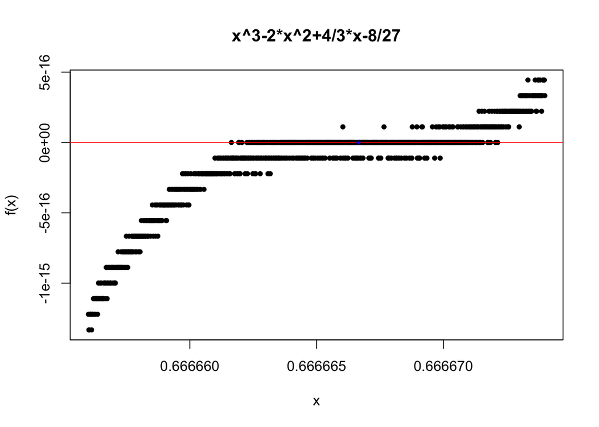

```r
x = seq(0.666656,0.666674,len=1000)
plot(x,f(x),pch=20,main="x^3-2*x^2+4/3*x-8/27")
abline(0,0,col="red")
points(2/3,0,col="blue",pch="*")
```

Do you have any ideas as to what might be happening? We’ll discuss this next week!

This is probably the approximation error associated with calculating very small floating point numbers related to how numbers are stored.

### Example 2: *Even when we don’t have multiple roots, issues can arise, as exemplified by the Wilkinson polynomial*

The Wilkinson polynomial is named after the numerical analyst James Wilkinson. It is defined as
$$W(x) = (x-1)(x-2)(x-3) ... (x-20),$$
which obviously has roots 1, 2, …, 20. Multiplied out this becomes
$$\begin{align}
W(x) &= 2432902008176640000 - 8752948036761600000*x + 13803759753640704000*x^2 - 12870931245150988800*x^3 \\
&+ 8037811822645051776*x^4 - 3599979517947607200*x^5 + 1206647803780373360*x^6 - 311333643161390640*x^7 \\
&+ 63030812099294896*x^8 - 10142299865511450*x^9 + 1307535010540395*x^{10} - 135585182899530*x^{11} \\
&+ 11310276995381*x^{12} - 756111184500*x^{13} + 40171771630*x^{14} -1672280820*x^{15}
+ 53327946*x^{16} \\ &- 1256850*x^{17} + 20615*x^{18} - 210*x^{19} + x^{20}.\end{align}$$

Here is the function defined in two different forms and plotted

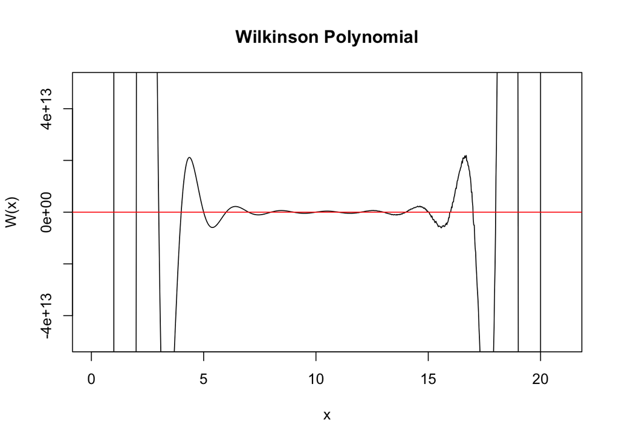

```r
# Function defined in factored format
Wilkinson = function(x) {
  (-20 + x)*(-19 + x)*(-18 + x)*(-17 + x)*(-16 + x)*(-15 + x)*(-14 + x)*(-13 + x)*
    (-12 + x)*(-11 + x)*(-10 + x)*(-9 + x)*(-8 + x)*(-7 + x)*(-6 + x)*(-5 + x)*(-4 + x)*
    (-3 + x)*(-2 + x)*(-1 + x)
}

# Function defined in expanded format
W = function(x){
  2432902008176640000 - 8752948036761600000*x + 13803759753640704000*x^2 -
    12870931245150988800*x^3 + 8037811822645051776*x^4 - 3599979517947607200*x^5  +
    1206647803780373360*x^6 - 311333643161390640*x^7 + 63030812099294896*x^8 -
    10142299865511450*x^9 + 1307535010540395*x^10 - 135585182899530*x^11 +
    11310276995381*x^12 - 756111184500*x^13 + 40171771630*x^14 -1672280820*x^15 +
    53327946*x^16 - 1256850*x^17 + 20615*x^18 - 210*x^19 + x^20
}

# Plot the Wilkinson polynomial
x = seq(0,21,len=1000)
plot(x,W(x),type="l",ylim=c(-5e13,5e13),main="Wilkinson Polynomial")
abline(0,0,col="red")
```

Note that I used the `ylim` parameter to set the range that is plotted on the $y$-axis.

1. Use `bisect` and `uniroot` to find the root at 16. Use the bracketing interval $[15.8,16.3]$ and use the unfactored form `W` of the polynomial. How many decimal places does it get correct? Note: with the factored version, it finds it exactly but that isn’t so useful, because if we have a function nicely factored, we don’t need to do numerical root-finding!

The bisect funtion gets this correct to two decimal places in 33 iterations.

```r
wInt = c(15.8, 16.3)
uniroot(W, wInt)
```

```
## $root
## [1] 16.0065135
##
## $f.root
## [1] -9126805504
##
## $iter
## [1] 11
##
## $init.it
## [1] NA
##
## $estim.prec
## [1] 6.103515626e-05
```

This also gets the correct answer to 2 decimal places but it only takes 11 iterations so it is much faster.

2. This led Wilkinson to say in 1984: “Speaking for myself, I regard it as the most traumatic experience of my career as a numerical analyst.” To feel his trauma, evaluate the function `W` at the root you computed in part a. What do you get? What should it be?

```r
#Bisect
W(16.00587) #-613911887872
```

```
## [1] -613911887872
```

```r
#Uniroot
W(16.00651) #7516192768
```

```
## [1] 7516192768
```

We get not 0 for both, but should be getting 0 for each.

3. Here is a new polynomial

```r
W2 = function(x){
  2432902008176640000 - 8752948036761600000*x + 13803759753640704000*x^2 -
    12870931245150988800*x^3 + 8037811822645051776*x^4 - 3599979517947607200*x^5  +
    1206647803780373360*x^6 - 311333643161390640*x^7 + 63030812099294896*x^8 -
    10142299865511450*x^9 + 1307535010540395*x^10 - 135585182899530*x^11 +
    11310276995381*x^12 - 756111184500*x^13 + 40171771630*x^14 -1672280820*x^15 +
    53327946*x^16 - 1256850*x^17 + 20615*x^18 - (210+2^(-23))*x^19 + x^20
}
```

It is the same as the Wilkinson polynomial, except I have changed the coefficient of $x^{19}$ by reducing it from $-210$ to $-(210 + 2^{-23})$. This is a relatively small change in the problem. See what the root that was at $x = 20$ increases to after this change has been made. Look for it in the interval $[19.5,20.95]$. Huge error magnification is caused by small relative errors in storing the coefficients. This is an impressive example of ill-conditioning, which we’ll discuss later.